# Finger Winkling Data

Peter Kamerman

15 October 2015

## Import and check the grading data

```r
# Read the data from 'grading.csv' into R
data <- read.csv("grading.csv", header = T)

# Check the data
head(data)
```

```
ID      Intervention  Hand Time WrinkleGrade
```

1 ID01 LocalAnaesthestic Right 5 0 2 ID02 LocalAnaesthestic Right 5 0 3 ID03 LocalAnaesthestic Right 5 0 4 ID04 LocalAnaesthestic Right 5 0 5 ID05 LocalAnaesthestic Right 5 0 6 ID06 LocalAnaesthestic Right 5 0

```r
tail(data)
```

```
  ID   Intervention Hand Time WrinkleGrade
```

235 ID25 WaterImmersion Left 30 1 236 ID26 WaterImmersion Left 30 1 237 ID27 WaterImmersion Left 30 0 238 ID28 WaterImmersion Left 30 1 239 ID29 WaterImmersion Left 30 3 240 ID30 WaterImmersion Left 30 4

```r
str(data)
```

‘data.frame’: 240 obs. of 5 variables: $ ID : Factor w/ 30 levels “ID01”,“ID02”,..: 1 2 3 4 5 6 7 8 9 10 … $ Intervention: Factor w/ 2 levels “LocalAnaesthestic”,..: 1 1 1 1 1 1 1 1 1 1 … $ Hand : Factor w/ 2 levels “Left”,“Right”: 2 2 2 2 2 2 2 2 2 2 … $ Time : int 5 5 5 5 5 5 5 5 5 5 … $ WrinkleGrade: int 0 0 0 0 0 0 0 0 0 0 …

```r
# Data summary
library(dplyr)
library(knitr)
summ <- data %>% tbl_df() %>% group_by(Time, Intervention) %>% summarise(Median = median(WrinkleGrade),
    Quartile.25 = quantile(WrinkleGrade, 0.25), Quartile.75 = quantile(WrinkleGrade,
        0.75))
kable(summ, align = "l", digits = 1, format = "markdown")
```

| Time | Intervention | Median | Quartile.25 | Quartile.75 |
| --- | --- | --- | --- | --- |
| 5 | LocalAnaesthestic | 0 | 0 | 0.0 |
| 5 | WaterImmersion | 0 | 0 | 1.0 |
| 10 | LocalAnaesthestic | 0 | 0 | 1.0 |
| 10 | WaterImmersion | 1 | 0 | 1.8 |
| 20 | LocalAnaesthestic | 1 | 0 | 1.0 |
| 20 | WaterImmersion | 1 | 0 | 2.0 |
| 30 | LocalAnaesthestic | 1 | 0 | 1.8 |
| 30 | WaterImmersion | 1 | 1 | 3.0 |

## Quick plot

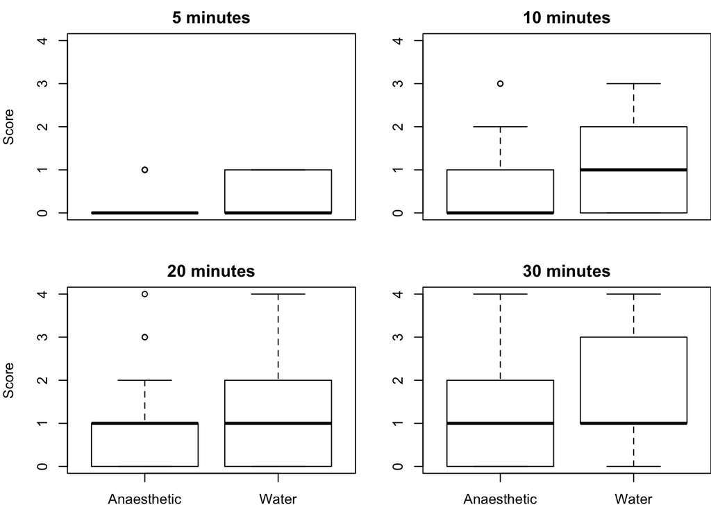

```r
# Set layout
par(mfrow = c(2, 2))
par(mar = c(2, 4, 2, 0))

# time = 5 minutes
boxplot(WrinkleGrade ~ Intervention, data = data[data$Time == 5, ], xaxt = "n",
    ylim = c(0, 4), ylab = "Score", main = "5 minutes")
# time = 10 minutes
boxplot(WrinkleGrade ~ Intervention, data = data[data$Time == 10, ], xaxt = "n",
    ylim = c(0, 4), main = "10 minutes")
# time = 20 minutes
boxplot(WrinkleGrade ~ Intervention, data = data[data$Time == 20, ], names = c("Anaesthetic",
    "Water"), ylim = c(0, 4), ylab = "Score", main = "20 minutes")
# time = 30 minutes
boxplot(WrinkleGrade ~ Intervention, data = data[data$Time == 30, ], names = c("Anaesthetic",
    "Water"), ylim = c(0, 4), main = "30 minutes")
```

## Statistical comparison at each time point

- *Comparisons made using Wilcoxon signed-rank test*
- *p-values are corrected for multiple comparisons (Bonferroni method)*

```r
# Create a function that performs a Wilcoxon signed-rank test, and corrects
# for multiple comparisons
wilx <- function(dat = data, time = 5) {
    dat.2 <- subset(dat, dat$Time == time)
    w <- wilcox.test(WrinkleGrade ~ Intervention, paired = T, exact = F, data = dat.2)
    w$p.value <- w$p.value * 4
    return(w)
}

# Run the function at each time interval
for (i in c(5, 10, 20, 30)) {
    w <- wilx(dat = data, time = i)
    print(paste("time =", i, "minutes"))
    print(w)
}
```

```
## [1] "time = 5 minutes"
##
##  Wilcoxon signed rank test with continuity correction
##
## data:  WrinkleGrade by Intervention
## V = 28, p-value = 0.7118
## alternative hypothesis: true location shift is not equal to 0
##
## [1] "time = 10 minutes"
##
##  Wilcoxon signed rank test with continuity correction
##
## data:  WrinkleGrade by Intervention
## V = 49, p-value = 1.228
## alternative hypothesis: true location shift is not equal to 0
##
## [1] "time = 20 minutes"
##
##  Wilcoxon signed rank test with continuity correction
##
## data:  WrinkleGrade by Intervention
## V = 56, p-value = 0.3994
## alternative hypothesis: true location shift is not equal to 0
##
## [1] "time = 30 minutes"
##
##  Wilcoxon signed rank test with continuity correction
##
## data:  WrinkleGrade by Intervention
## V = 37, p-value = 0.1337
## alternative hypothesis: true location shift is not equal to 0
```